# Simulations for `norm_glsx_mix_qic_corstr_sim.R`

# System setup

```r
R <- list.files(path = "./simulations/R", pattern = "*.R", full.names = TRUE)
sapply(R, source, .GlobalEnv)
library(knitr)
library(kableExtra)
```

# Setting

## Data

Following Wang *et al.* (2012) with one-hundred replications, the correlated normal responses are generated from the model
$$y_{ij} = \mathbf{X}_{ij}^{\top}\boldsymbol{\beta}
+ \varepsilon_{ij},$$
where $i = 1, \ldots, 200,$ $j = 1, \ldots, 4,$ $\mathbf{X}_{ij} = (x_{ij, 1}, \ldots, x_{ij, 6})^{\top},$ and $\boldsymbol{\beta} = (2.0, 3.0, 0.5, 0.0, 0.0, 0.0)^{\top}.$

- For the covariates,
  - $x_{ij,1}$ was generated from the Bernoulli(0.5) distribution, and
  - each $x_{ij,k}$ for $k = 2 \ldots 6$ was generated from the multivariate normal distribution with mean 0 and an AR(1) covariance matrix with marginal variance 1 and auto-correlation coefficient 0.5.
- The random errors $(\varepsilon_{i1}, \ldots, \varepsilon_{i4})^{\top}$ are generated from the multivariate normal distribution with marginal mean 0, marginal variance 1, and an exchangeable correlation matrix with $\rho = 0.5$.

## Transformation of the response and covariate matrix

After the data was simulated, the response, $\mathbf{y},$ and the covariate matrix, $\mathbf{X},$ was transformed by:

1. fitting a fully saturated model with an unstructured working correlation matrix,
2. calculating $\mathbf{V}_{i} = \phi \mathbf{A}_{i}^{1/2}\mathbf{R}_{i}(\boldsymbol{\alpha})\mathbf{A}_{i}^{1/2}$ and finding $\mathbf{V}_{i}^{-1/2}$, and
3. obtaining $\mathbf{y}^{*} = \mathbf{V}_{i}^{-1/2}\mathbf{y}$ and $\mathbf{X}^{*} = \mathbf{V}_{i}^{-1/2}\mathbf{X}$.

## Best subsets

```r
nsims <- 100L
beta <- c(2.0, 3.0, 0.5, 0.0, 0.0, 0.0)
w <- which(beta != 0)
l <- length(w)
```

# Results

The simulation results are stored in:

```r
load("./simulations/outputs/norm_glsx_mix_qic_corstr_sim/norm_glsx_mix_qic_corstr_sim.RData")
```

## IC across the simulations

Now for each of the models with the minimum IC, the criterion will be broken into its parts to see what is impacting the selection process. Additionally, this provides a look at the stability of the information criterion across the simulations. For these simulations, the goodness-of-fit (GOF) term was derived using either the likelihood or quasi-likelihood framework. When GLMs were used to fit the transformed response, the GOF was based on traditional likelihood. While when GEEs were used, the GOF was based on quasi-likelihood that assumes independence among the observations of the response. Unlike the GOF term, the penalty term of each IC was calculated using GEEs. The penalty is $2tr\left(\widehat{\boldsymbol{\Omega}}_{I}\widehat{\mathbf{V}}_{R}\right)$, where $\widehat{\boldsymbol{\Omega}}_{I}$ and $\widehat{\mathbf{V}}_{R}$ are estimated using the original data data. Remember that $2tr\left(\widehat{\boldsymbol{\Omega}}_{I}\widehat{\mathbf{V}}_{R}\right)$ is the penalty term used in QIC and CIC, and is needed when simulataneous selection of the mean and correlation structure is of interest. If selection of correlation structure is **not** needed, then QICu, AIC, or BIC could be used because the penalty term is focused on the number of parameters estimated.

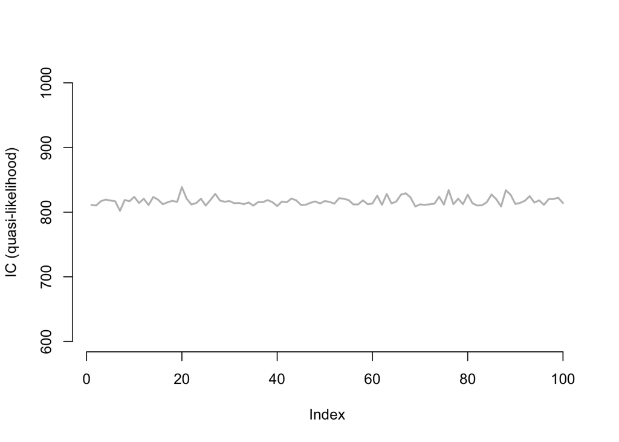

```r
ic_quasi <- sapply(res_quasi, function(x) x$ic_min, simplify = TRUE)
ic_lik <- sapply(res_lik, function(x) x$ic_min, simplify = TRUE)

plot(
  x = seq_len(nsims), y = ic_quasi,
  ylim = c(600, 1000),
  xlab = "Index", ylab = "IC (quasi-likelihood)",
  type = "l", lwd = 2, col = "gray",
  bty = "n"
)
```

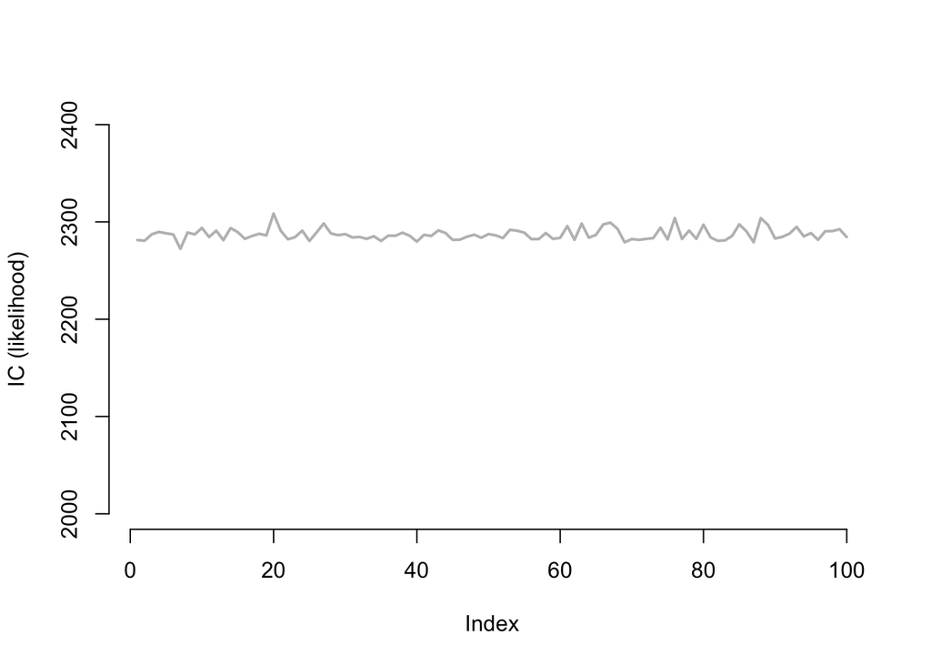

```r
plot(
  x = seq_len(nsims), y = ic_lik,
  ylim = c(2000, 2400),
  xlab = "Index", ylab = "IC (likelihood)",
  type = "l", lwd = 2, col = "gray",
  bty = "n"
)
```

### Goodness-of-fit

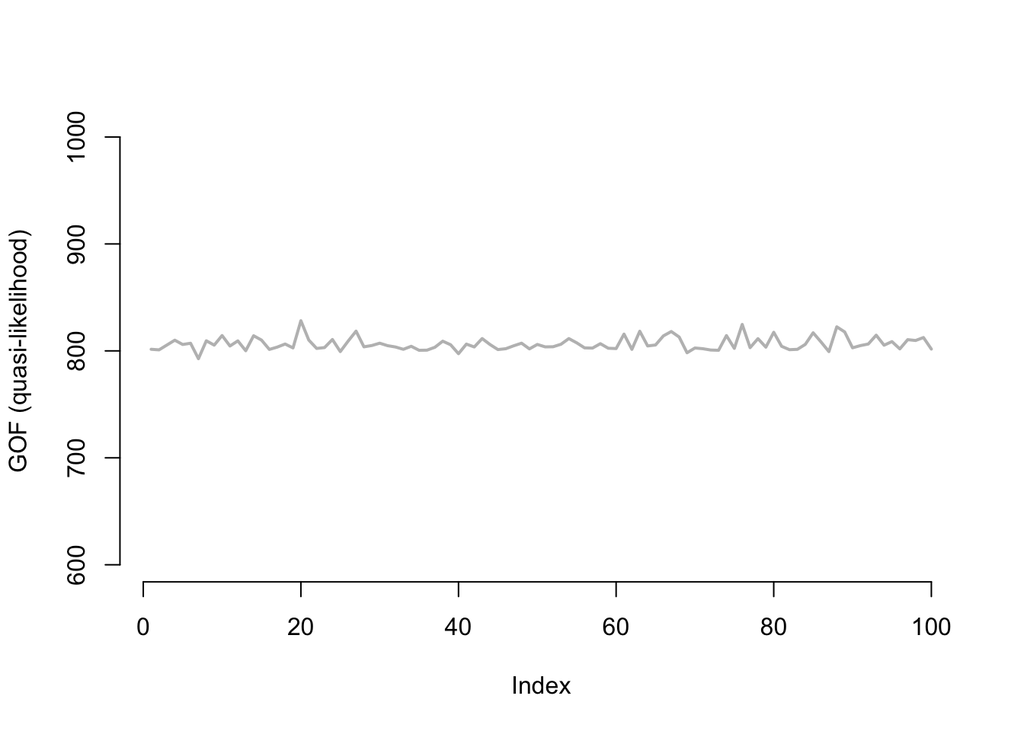

```r
gf_quasi <- gf_lik <- rep(NA, nsims)
for (k in seq_len(nsims)) {
  w_quasi <- res_quasi[[k]]$min
  w_lik <- res_lik[[k]]$min
  gf_quasi[k] <- res_quasi[[k]]$gof[w_quasi]
  gf_lik[k] <- res_lik[[k]]$gof[w_lik]
}

plot(
  x = seq_len(nsims), y = gf_quasi,
  ylim = c(600, 1000),
  xlab = "Index", ylab = "GOF (quasi-likelihood)",
  type = "l", lwd = 2, col = "gray",
  bty = "n"
)
```

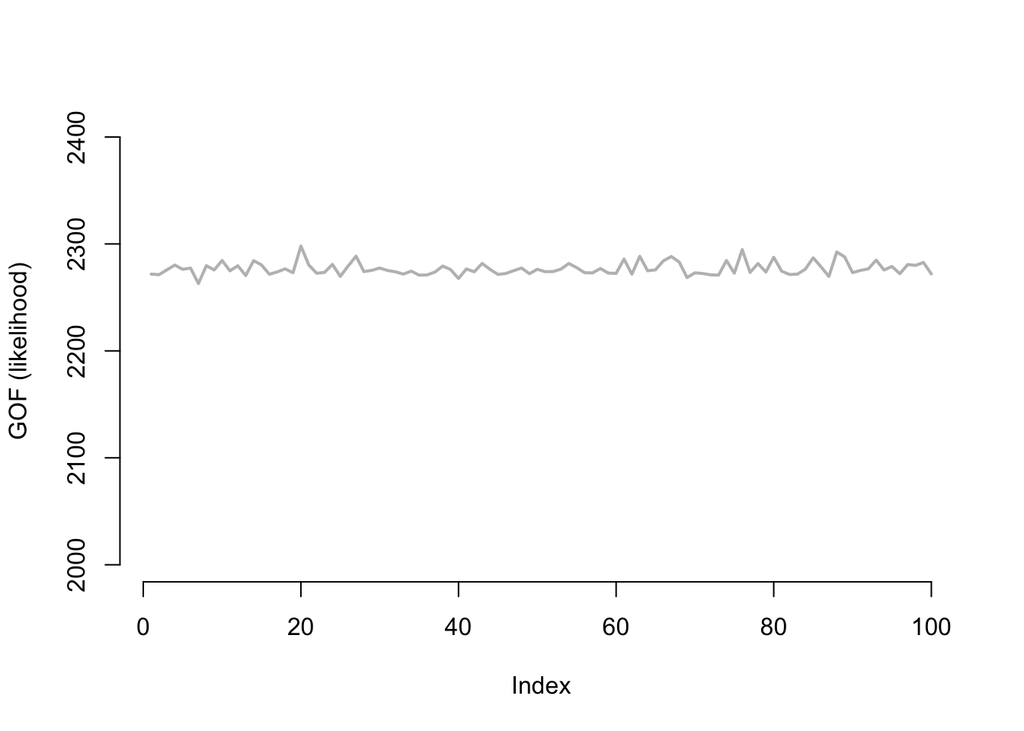

```r
plot(
  x = seq_len(nsims), y = gf_lik,
  ylim = c(2000, 2400),
  xlab = "Index", ylab = "GOF (likelihood)",
  type = "l", lwd = 2, col = "gray",
  bty = "n"
)
```

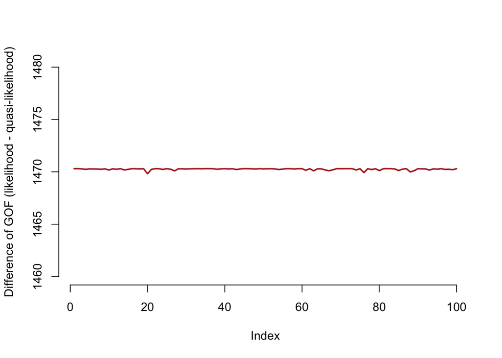

```r
plot(
  x = seq_len(nsims), y = gf_lik - gf_quasi,
  ylim = c(1460, 1480),
  xlab = "Index", ylab = "Difference of GOF (likelihood - quasi-likelihood)",
  type = "l", lwd = 2, col = "firebrick",
  bty = "n"
)
```

### Penalty

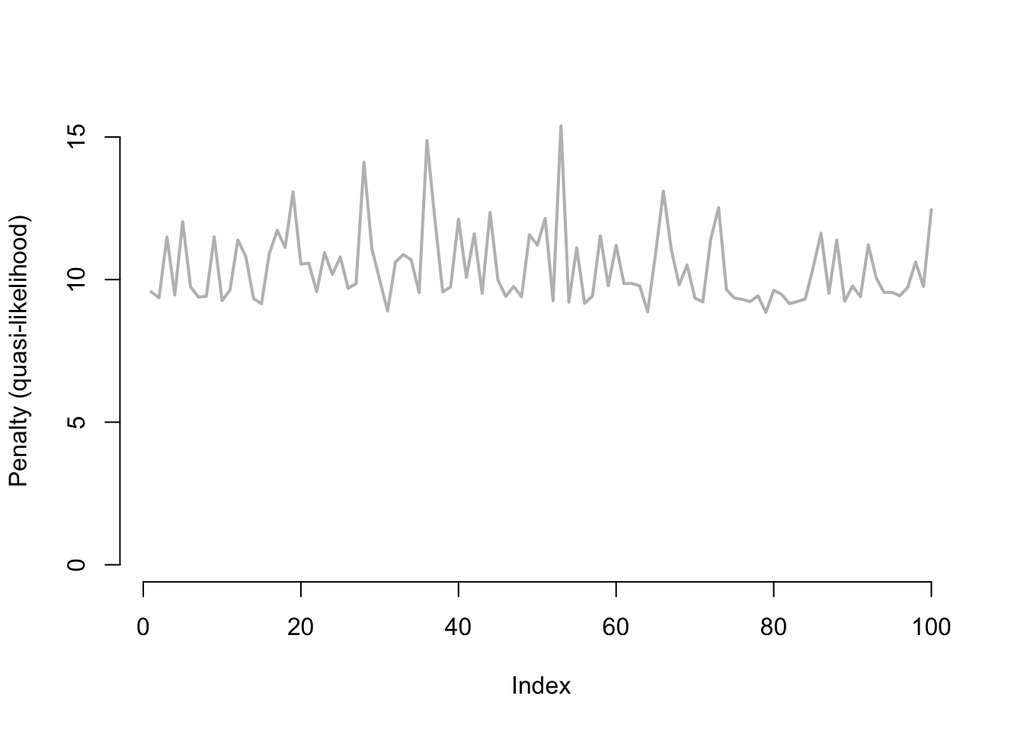

```r
pen_quasi <- pen_lik <-  rep(NA, nsims)
for (k in seq_len(nsims)) {
  w_quasi <- res_quasi[[k]]$min
  w_lik <- res_lik[[k]]$min
  pen_quasi[k] <- res_quasi[[k]]$penalty[w_quasi]
  pen_lik[k] <- res_lik[[k]]$penalty[w_lik]
}

plot(
  x = seq_len(nsims), y = pen_quasi,
  ylim = c(0, 15),
  xlab = "Index", ylab = "Penalty (quasi-likelihood)",
  type = "l", lwd = 2, col = "gray",
  bty = "n"
)
```

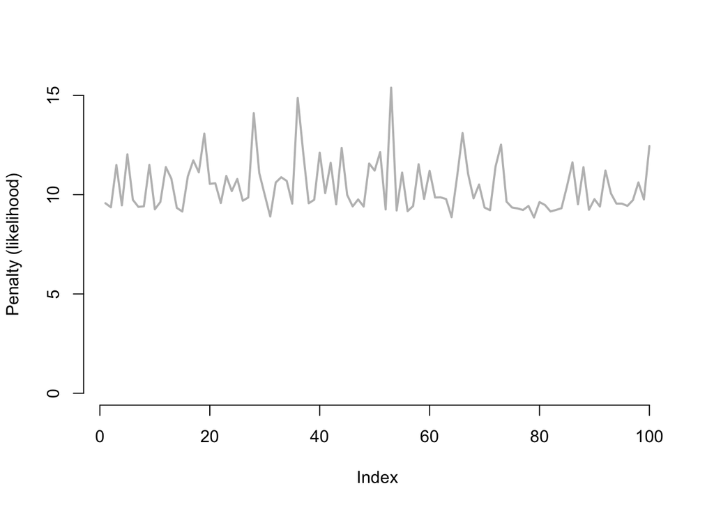

```r
plot(
  x = seq_len(nsims), y = pen_lik,
  ylim = c(0, 15),
  xlab = "Index", ylab = "Penalty (likelihood)",
  type = "l", lwd = 2, col = "gray",
  bty = "n"
)
```

## Structure selection based on IC

### Mean

For measuring the overall performance of selecting the mean structure, a function will be created called `look` that reports the number of models, where

- the number of features selected is less than the number of non-zero coefficients in the generating model (`under`),
- only the non-zero features from the generating model were selected (`exact`),
- the number of features selected matches the number of non-zero coefficients in the generating model; however, at least one of the selected features is NOT one of the non-zero effects in the generating model (`mis`),
- the number of features selected is greated than the number of non-zero coefficients in the generating model (`over`), and
- the number of features selected is greated than the number of non-zero coefficients in the generating model and includes all the non-zero effects (`over_inc`).

```r
# creating a function to generate a look at the simulation results
look <- function(x) {
  under <- 0
  exact <- 0
  mis <- 0
  over <- 0
  over_inc <- 0
  for (k in seq_along(x)) {
    under <- under + (length(x[[k]]$vars) < l)
    exact <- exact + identical(x[[k]]$vars, w)
    mis <- mis + (!identical(x[[k]]$vars, w) & (length(x[[k]]$vars) == l))
    over <- over + (length(x[[k]]$vars) > l)
    over_inc <- over_inc + ((length(x[[k]]$vars) > l) & all(w %in% x[[k]]$vars))
  }
  return(
    data.frame(
      under = under, exact = exact,
      mis = mis, over = over,
      over_inc = over_inc
    )
  )
}
```

Using the `look` function, we have the following summary measures from the simulation set, where the models resulting in the minimum IC value were selected as the best fitting model and the counts are based on likelihood framework used to define the GOF term.

```r
data.frame(
    lik = c("Quasi-likelihood", "Likelihood"),
    dplyr::bind_rows(look(res_quasi), look(res_lik))
)
```

```
##                lik under exact mis over over_inc
## 1 Quasi-likelihood     0    59   0   41       41
## 2       Likelihood     0    59   0   41       41
```

### Correlation

Now for measuring the overall performance of selecting the correlation structure, the table below presents the number of models, where the correlation structure selected from the best subsets was AR(1) (`ar1`), exchangeable (`exchangeable`), and independence (`independence`). Note that proper selection of the mean structure is not needed to select the correlation structure correctly.

```r
corstr_quasi <- sapply(res_quasi, function(x) x$corstr_min, simplify = TRUE)
corstr_lik <- sapply(res_lik, function(x) x$corstr_min, simplify = TRUE)

corstr_count <- function(x) {
  count_indp <- 0
  count_cs <- 0
  count_ar1 <- 0
  count_un <- 0
  for (i in seq_along(x)) {
    count_indp <- count_indp + (x[i] == "independence")
    count_cs <- count_cs + (x[i] == "exchangeable")
    count_ar1 <- count_ar1 + (x[i] == "ar1")
    count_un <- count_un + (x[i] == "unstructured")
  }
  temp <- data.frame(
    indpendenence = count_indp, exchangeable = count_cs,
    ar1 = count_ar1, un = count_un
  )
  return(temp)
}

data.frame(
  lik = c("Quasi-likelihood", "Likelihood"),
  dplyr::bind_rows(corstr_count(corstr_quasi), corstr_count(corstr_lik))
)
```

```
##                lik indpendenence exchangeable ar1 un
## 1 Quasi-likelihood             0           13   0 87
## 2       Likelihood             0           13   0 87
```

### Joint

```r
joint <- function(x) {
  p <- function(y) {
    if (length(y) == 0) {
      return(data.frame(under = 0, exact = 0, mis = 0, over = 0, over_inc = 0))
    } else {
      return(look(x = y))
    }
  }

  independence <- x[sapply(x, function(x) x$corstr_min == "independence", simplify = TRUE)]
  exchangeable <- x[sapply(x, function(x) x$corstr_min == "exchangeable", simplify = TRUE)]
  ar1 <- x[sapply(x, function(x) x$corstr_min == "ar1", simplify = TRUE)]
  un <- x[sapply(x, function(x) x$corstr_min == "unstructured", simplify = TRUE)]

  ip <- p(independence)
  ep <- p(exchangeable)
  ap <- p(ar1)
  up <- p(un)

  return(dplyr::bind_rows(ip, ep, ap, up))
}

data.frame(
  lik = c("Quasi-likelihood", "", "", "", "Likelihood", "", "", ""),
  corstr = rep(c("Independence", "Exchangeable", "AR(1)", "Unstructured"), 2),
  dplyr::bind_rows(joint(res_quasi), joint(res_lik))
)
```

```
##                lik       corstr under exact mis over over_inc
## 1 Quasi-likelihood Independence     0     0   0    0        0
## 2                  Exchangeable     0     7   0    6        6
## 3                         AR(1)     0     0   0    0        0
## 4                  Unstructured     0    52   0   35       35
## 5       Likelihood Independence     0     0   0    0        0
## 6                  Exchangeable     0     7   0    6        6
## 7                         AR(1)     0     0   0    0        0
## 8                  Unstructured     0    52   0   35       35
```